# Diabetes Prediction

Lara White

# Data Overview

```r
diabetes = read.csv(file= "C:/Users/Lara/OneDrive/Desktop/r_projects/MATH327/diabetes.csv")

head(diabetes)
```

```
##   Pregnancies Glucose BloodPressure SkinThickness Insulin  BMI
## 1           6     148            72            35       0 33.6
## 2           1      85            66            29       0 26.6
## 3           8     183            64             0       0 23.3
## 4           1      89            66            23      94 28.1
## 5           0     137            40            35     168 43.1
## 6           5     116            74             0       0 25.6
##   DiabetesPedigreeFunction Age Outcome
## 1                    0.627  50       1
## 2                    0.351  31       0
## 3                    0.672  32       1
## 4                    0.167  21       0
## 5                    2.288  33       1
## 6                    0.201  30       0
```

```r
summary(diabetes)
```

```
##   Pregnancies        Glucose      BloodPressure    SkinThickness
##  Min.   : 0.000   Min.   :  0.0   Min.   :  0.00   Min.   : 0.00
##  1st Qu.: 1.000   1st Qu.: 99.0   1st Qu.: 62.00   1st Qu.: 0.00
##  Median : 3.000   Median :117.0   Median : 72.00   Median :23.00
##  Mean   : 3.845   Mean   :120.9   Mean   : 69.11   Mean   :20.54
##  3rd Qu.: 6.000   3rd Qu.:140.2   3rd Qu.: 80.00   3rd Qu.:32.00
##  Max.   :17.000   Max.   :199.0   Max.   :122.00   Max.   :99.00
##     Insulin           BMI        DiabetesPedigreeFunction      Age
##  Min.   :  0.0   Min.   : 0.00   Min.   :0.0780           Min.   :21.00
##  1st Qu.:  0.0   1st Qu.:27.30   1st Qu.:0.2437           1st Qu.:24.00
##  Median : 30.5   Median :32.00   Median :0.3725           Median :29.00
##  Mean   : 79.8   Mean   :31.99   Mean   :0.4719           Mean   :33.24
##  3rd Qu.:127.2   3rd Qu.:36.60   3rd Qu.:0.6262           3rd Qu.:41.00
##  Max.   :846.0   Max.   :67.10   Max.   :2.4200           Max.   :81.00
##     Outcome
##  Min.   :0.000
##  1st Qu.:0.000
##  Median :0.000
##  Mean   :0.349
##  3rd Qu.:1.000
##  Max.   :1.000
```

# Data Characteristics

In this section, we will explore some of the variables and look into the nature of data.

```r
library(MASS)
table1= with (diabetes, xtabs(~Outcome+Pregnancies))
table1
```

```
##        Pregnancies
## Outcome   0   1   2   3   4   5   6   7   8   9  10  11  12  13  14  15  17
##       0  73 106  84  48  45  36  34  20  16  10  14   4   5   5   0   0   0
##       1  38  29  19  27  23  21  16  25  22  18  10   7   4   5   2   1   1
```

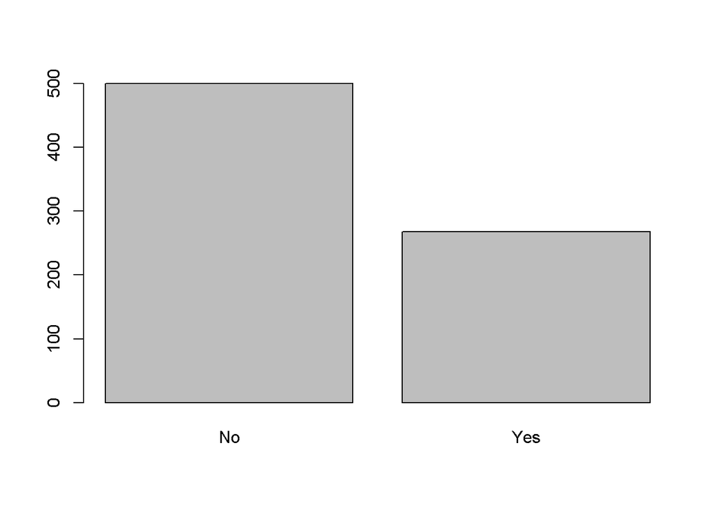

```r
barplot (with (diabetes,
 table (ifelse (Outcome==1, "Yes", "No")),
 xlab="Disease Status", ylab="# Subjects"))
```

Most of the patients didn’t have diabetes. The people with diabetes is around the half of the people with no diabetes.

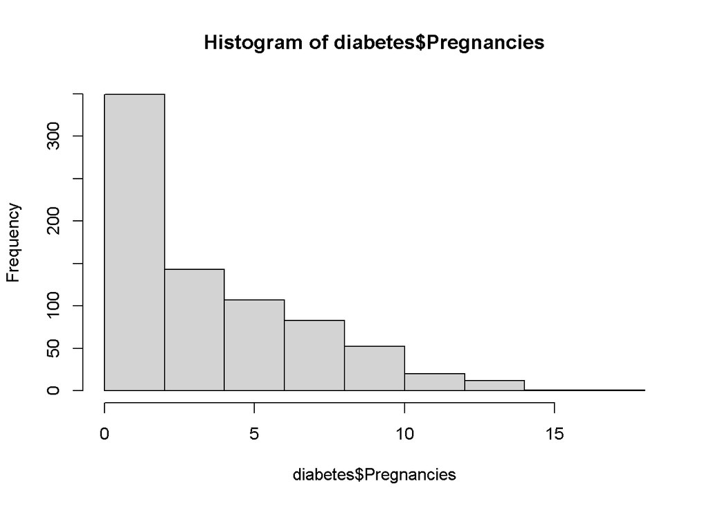

```r
hist(diabetes$Pregnancies)
```

The data is right skewed with most of the patients having less than 5 pregnancies.

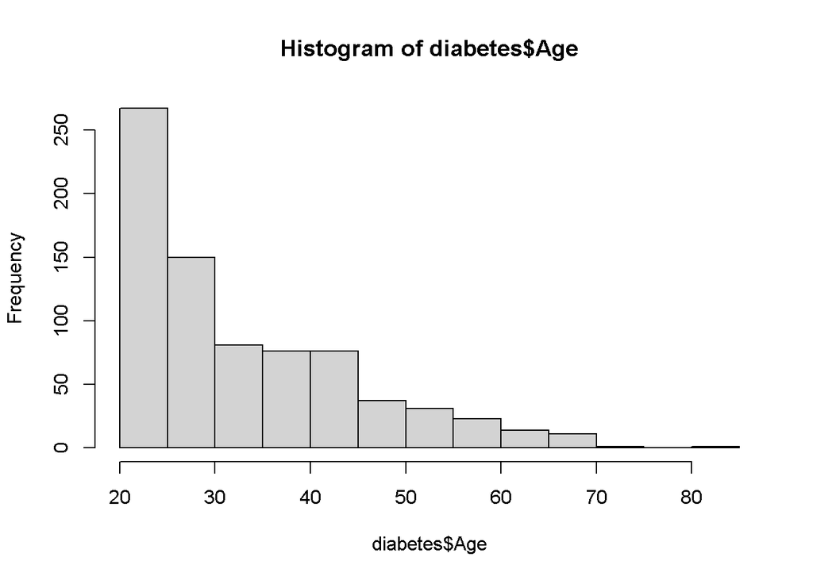

```r
hist(diabetes$Age)
```

Most patients were between 20 to 30 years old with huge number of patients being between 20 to 25 years old.It suggests that most of the patients are adults

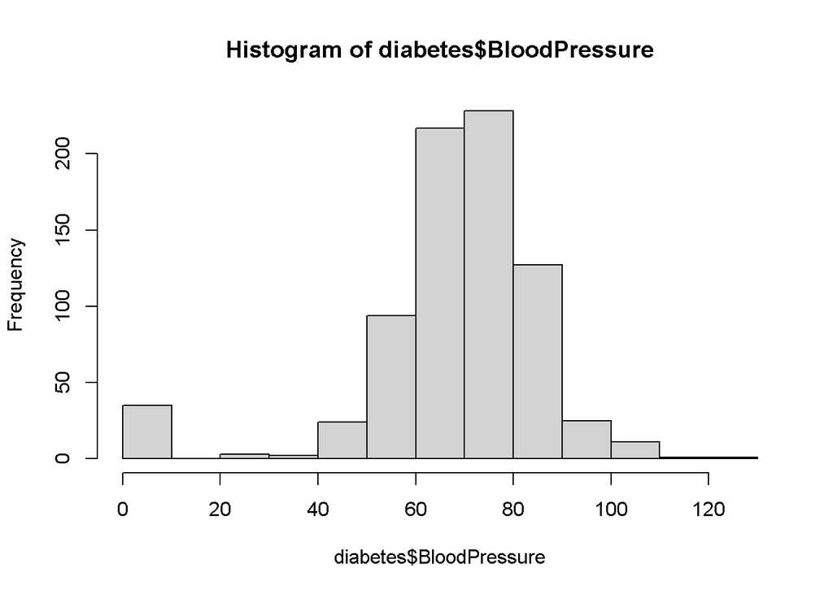

```r
hist(diabetes$BloodPressure)
```

The histogram for the blood pressure is symmetric. Having too low or too high blood pressure is harmful for health.

Plotting the response vs each quantitative predictor in a separate panel with a smoothing spline fit:

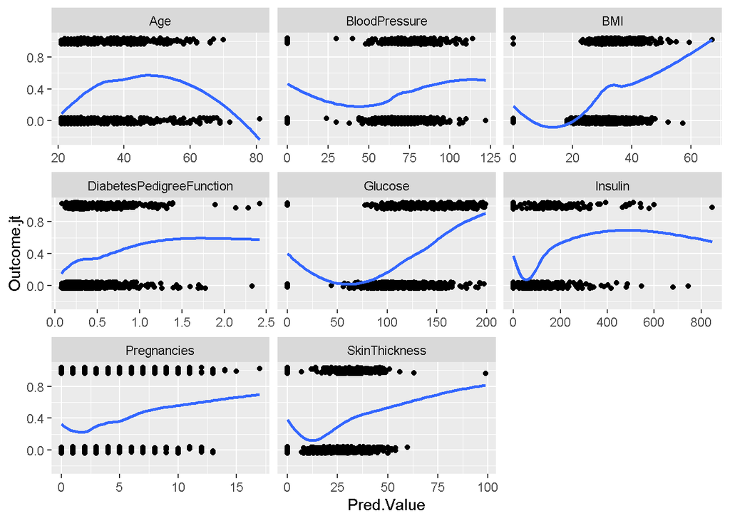

```r
library(ggplot2)
library(tidyr)
library(dplyr)
# Assuming the Outcome is named Outcome in your dataset
dis.stack <- diabetes %>%
  pivot_longer(!Outcome, names_to = "Pred.Name", values_to = "Pred.Value") %>%
  mutate(Outcome.jt = jitter(Outcome, 0.2))

qplot(Pred.Value, Outcome.jt, data = dis.stack) +
  facet_wrap(~Pred.Name, scales = 'free_x') +
  geom_smooth(method = "loess", se = FALSE)
```

# First Order Transformation

```r
diabetes.logit = glm(Outcome ~ Pregnancies + Glucose +
                       BloodPressure + SkinThickness +
                       Insulin + BMI + DiabetesPedigreeFunction +
                       Age, data = diabetes, family = binomial)

summary(diabetes.logit)
```

```
##
## Call:
## glm(formula = Outcome ~ Pregnancies + Glucose + BloodPressure +
##     SkinThickness + Insulin + BMI + DiabetesPedigreeFunction +
##     Age, family = binomial, data = diabetes)
##
## Coefficients:
##                            Estimate Std. Error z value Pr(>|z|)
## (Intercept)              -8.4046964  0.7166359 -11.728  < 2e-16 ***
## Pregnancies               0.1231823  0.0320776   3.840 0.000123 ***
## Glucose                   0.0351637  0.0037087   9.481  < 2e-16 ***
## BloodPressure            -0.0132955  0.0052336  -2.540 0.011072 *
## SkinThickness             0.0006190  0.0068994   0.090 0.928515
## Insulin                  -0.0011917  0.0009012  -1.322 0.186065
## BMI                       0.0897010  0.0150876   5.945 2.76e-09 ***
## DiabetesPedigreeFunction  0.9451797  0.2991475   3.160 0.001580 **
## Age                       0.0148690  0.0093348   1.593 0.111192
## ---
## Signif. codes:  0 '***' 0.001 '**' 0.01 '*' 0.05 '.' 0.1 ' ' 1
##
## (Dispersion parameter for binomial family taken to be 1)
##
##     Null deviance: 993.48  on 767  degrees of freedom
## Residual deviance: 723.45  on 759  degrees of freedom
## AIC: 741.45
##
## Number of Fisher Scoring iterations: 5
```